# 16S microbiome analysis across habitats: composition, diversity and compositional data

Adhithi Ravi Raghavan

October 2026

## Summary

This analysis explores 16S rRNA amplicon data from 26 samples across nine habitats (soil, ocean, freshwater, sediment, human gut, skin and tongue, plus mock communities) using the public **GlobalPatterns** dataset (Caporaso *et al.*, *PNAS* 2011), bundled with the `phyloseq` package.

The questions are:

1. **Is the data fit to analyse?** Sequencing depth, mock-community controls and low-prevalence taxa.
2. **How does community composition and diversity differ between habitats?**
3. **Do conclusions change when the data are treated as compositional?** 16S counts only carry relative information, so I compare a standard relative-abundance approach (Bray–Curtis) with a compositional one (centred log-ratio, CLR, and Aitchison distance).
4. **Which genera separate host-associated from environmental communities?**
5. **How sensitive are those results to the differential-abundance method?** I compare relative abundance, CLR and robust CLR, and check how zero handling changes the answer.
6. **Can habitat be predicted from community composition, and where does a model fail?** A random forest, evaluated with leave-one-out cross-validation against a shuffled-label baseline.

```r
library(phyloseq)
library(vegan)
library(ggplot2)
library(dplyr)
library(tidyr)
library(randomForest)
theme_set(theme_bw(base_size = 12))
```

## 1. Data and quality control

```r
data(GlobalPatterns)
gp <- GlobalPatterns
gp
```

```
## phyloseq-class experiment-level object
## otu_table()   OTU Table:         [ 19216 taxa and 26 samples ]
## sample_data() Sample Data:       [ 26 samples by 7 sample variables ]
## tax_table()   Taxonomy Table:    [ 19216 taxa by 7 taxonomic ranks ]
## phy_tree()    Phylogenetic Tree: [ 19216 tips and 19215 internal nodes ]
```

### Sequencing depth

Library sizes vary by more than an order of magnitude between samples, so raw counts cannot be compared directly.

```r
depth <- data.frame(
  sample = sample_names(gp),
  reads = sample_sums(gp),
  habitat = sample_data(gp)$SampleType
)
summary(depth$reads)
```

```
##    Min. 1st Qu.  Median    Mean 3rd Qu.    Max.
##   58688  567103 1106849 1085257 1527330 2357181
```

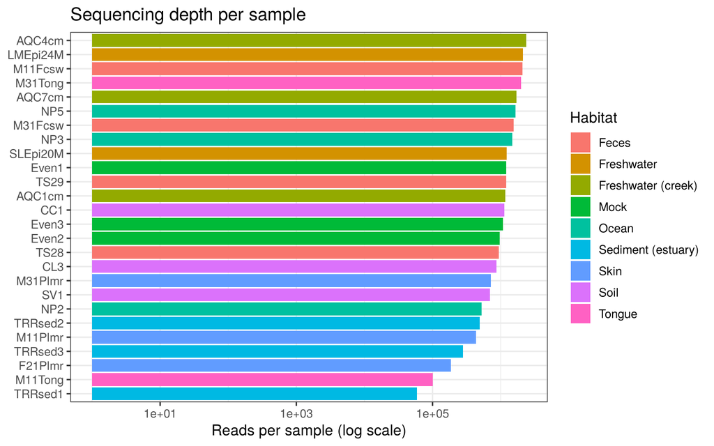

```r
ggplot(depth, aes(reorder(sample, reads), reads, fill = habitat)) +
  geom_col() +
  coord_flip() +
  scale_y_log10() +
  labs(x = NULL, y = "Reads per sample (log scale)", fill = "Habitat",
       title = "Sequencing depth per sample")
```

### Mock-community controls

Mock communities are built from a small, known set of strains, so they show how much apparent diversity comes from sequencing error, chimeras or contamination rather than biology.

```r
mock <- subset_samples(gp, SampleType == "Mock")
mock <- prune_taxa(taxa_sums(mock) > 0, mock)
mock_counts <- as(otu_table(mock), "matrix")
mock_rel <- sweep(mock_counts, 2, colSums(mock_counts), "/")
abundant <- apply(mock_rel, 1, max) >= 0.001

cat("Taxa observed in mock samples:        ", ntaxa(mock), "\n")
```

```
## Taxa observed in mock samples:         5842
```

```r
cat("Taxa at >= 0.1% in any mock sample:   ", sum(abundant), "\n")
```

```
## Taxa at >= 0.1% in any mock sample:    74
```

```r
cat("Share of mock reads in those taxa:    ",
    round(100 * sum(mock_counts[abundant, ]) / sum(mock_counts), 1), "%\n")
```

```
## Share of mock reads in those taxa:     96 %
```

Thousands of taxa appear in the mock samples, but a few dozen account for almost all the reads. The rest is a long tail of rare, mostly spurious taxa. Two practical consequences follow: raw richness counts overstate true diversity, and rare taxa should be filtered before comparing samples. Mock samples are removed before the biological comparisons below.

### Filtering

Taxa seen in very few samples add noise and inflate sparsity. I keep taxa present in at least 3 samples with at least 10 reads in total.

```r
gp_bio <- subset_samples(gp, SampleType != "Mock")
gp_bio <- prune_taxa(taxa_sums(gp_bio) > 0, gp_bio)

prevalence <- apply(otu_table(gp_bio), 1, function(x) sum(x > 0))
keep <- prevalence >= 3 & taxa_sums(gp_bio) >= 10
gp_f <- prune_taxa(keep, gp_bio)

cat("Taxa before filtering:", ntaxa(gp_bio), "\n")
```

```
## Taxa before filtering: 18773
```

```r
cat("Taxa after filtering: ", ntaxa(gp_f), "\n")
```

```
## Taxa after filtering:  10855
```

```r
cat("Reads retained:", round(100 * sum(sample_sums(gp_f)) / sum(sample_sums(gp_bio)), 1), "%\n")
```

```
## Reads retained: 99.7 %
```

## 2. Community composition

Counts are converted to relative abundances (proportions per sample), which removes differences in sequencing depth.

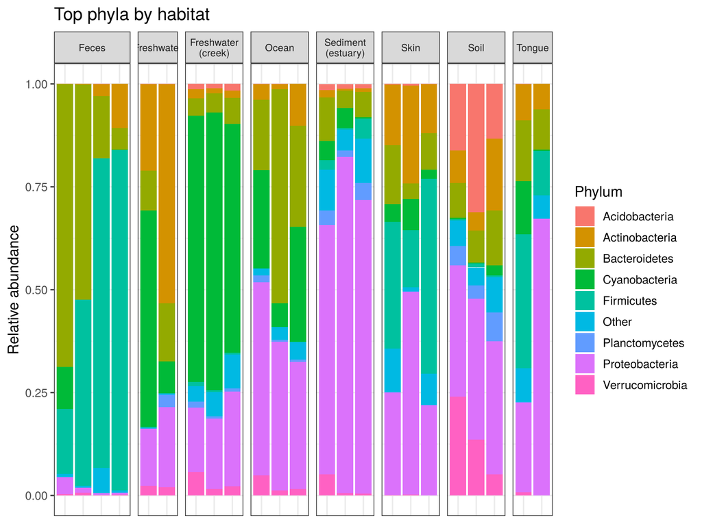

```r
gp_rel <- transform_sample_counts(gp_f, function(x) x / sum(x))
phylum <- tax_glom(gp_rel, taxrank = "Phylum")
phylum_df <- psmelt(phylum)

top_phyla <- phylum_df %>%
  group_by(Phylum) %>%
  summarise(mean_abund = mean(Abundance)) %>%
  slice_max(mean_abund, n = 8) %>%
  pull(Phylum)

phylum_df <- phylum_df %>%
  mutate(Phylum = ifelse(Phylum %in% top_phyla, as.character(Phylum), "Other"))

ggplot(phylum_df, aes(Sample, Abundance, fill = Phylum)) +
  geom_col() +
  facet_grid(~ SampleType, scales = "free_x", space = "free_x",
             labeller = label_wrap_gen(width = 10)) +
  labs(x = NULL, y = "Relative abundance", title = "Top phyla by habitat") +
  theme(axis.text.x = element_blank(), axis.ticks.x = element_blank(),
        strip.text = element_text(size = 8))
```

## 3. Alpha diversity

Richness estimates depend on sequencing depth, so I rarefy to the smallest library size for alpha diversity only, and repeat the comparison on unrarefied data as a check.

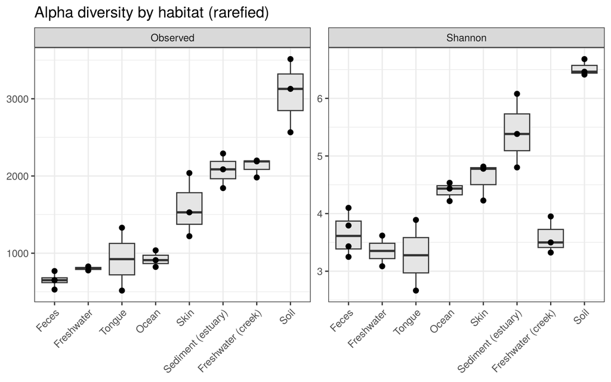

```r
gp_rare <- rarefy_even_depth(gp_f, rngseed = 42, verbose = FALSE)
alpha <- estimate_richness(gp_rare, measures = c("Observed", "Shannon"))
alpha$habitat <- sample_data(gp_rare)$SampleType

alpha_long <- pivot_longer(alpha, c(Observed, Shannon),
                           names_to = "metric", values_to = "value")

ggplot(alpha_long, aes(reorder(habitat, value), value)) +
  geom_boxplot(outlier.shape = NA, fill = "grey90") +
  geom_point(size = 2) +
  facet_wrap(~ metric, scales = "free_y") +
  labs(x = NULL, y = NULL, title = "Alpha diversity by habitat (rarefied)") +
  theme(axis.text.x = element_text(angle = 45, hjust = 1))
```

```r
kruskal.test(Shannon ~ habitat, data = alpha)
```

```
##
##  Kruskal-Wallis rank sum test
##
## data:  Shannon by habitat
## Kruskal-Wallis chi-squared = 19.306, df = 7, p-value = 0.00728
```

```r
alpha_raw <- estimate_richness(gp_f, measures = "Shannon")
cor.test(alpha$Shannon, alpha_raw$Shannon, method = "spearman")
```

```
##
##  Spearman's rank correlation rho
##
## data:  alpha$Shannon and alpha_raw$Shannon
## S = 0, p-value = 1.398e-06
## alternative hypothesis: true rho is not equal to 0
## sample estimates:
## rho
##   1
```

The ranking of samples by Shannon diversity is the same with and without rarefaction, so this conclusion does not depend on the normalisation choice.

## 4. Beta diversity: relative abundance vs compositional

### Bray–Curtis on relative abundances

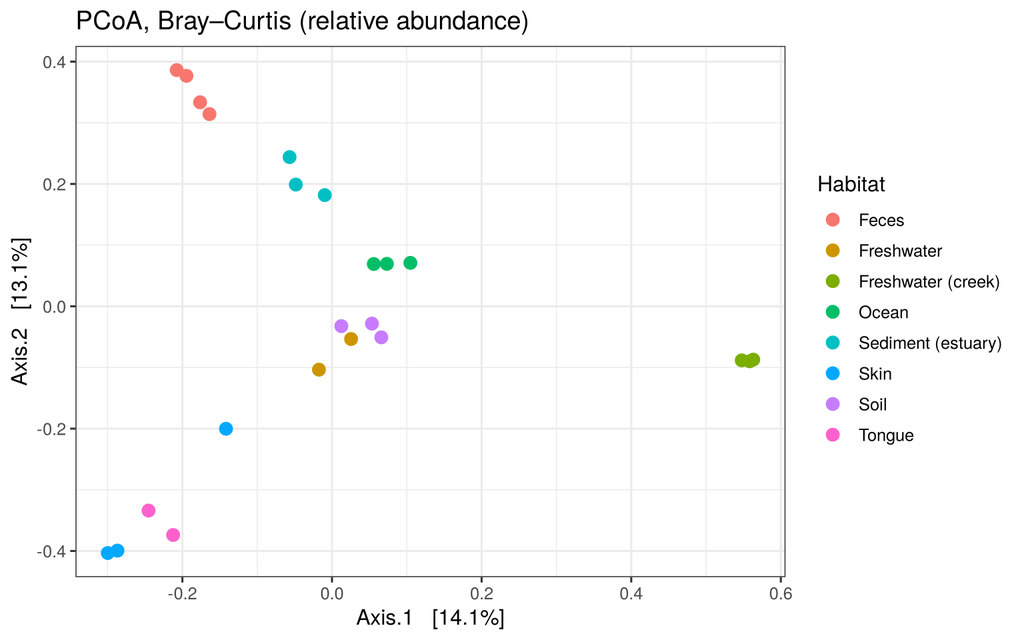

```r
bray <- phyloseq::distance(gp_rel, method = "bray")
pcoa_bray <- ordinate(gp_rel, method = "PCoA", distance = bray)

plot_ordination(gp_rel, pcoa_bray, color = "SampleType") +
  geom_point(size = 3) +
  labs(color = "Habitat", title = "PCoA, Bray–Curtis (relative abundance)")
```

### Aitchison distance on CLR-transformed counts

Relative abundances sum to 1, so they are not independent: an increase in one taxon forces apparent decreases in others. The **centred log-ratio (CLR)** transform takes the log of each taxon relative to the geometric mean of its sample. Euclidean distance on CLR values (the **Aitchison distance**) respects this compositional structure. Zeros are handled with a small pseudocount, a known limitation of this approach.

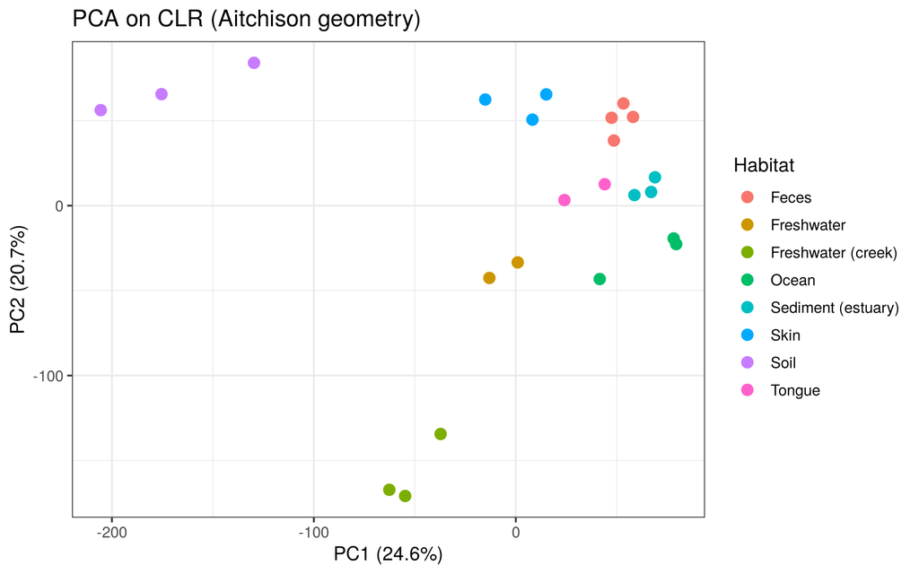

```r
counts <- as(otu_table(gp_f), "matrix")
if (taxa_are_rows(gp_f)) counts <- t(counts)   # samples x taxa

clr <- function(x, pseudocount = 0.5) {
  lx <- log(x + pseudocount)
  lx - rowMeans(lx)
}
clr_mat <- clr(counts)

pca_clr <- prcomp(clr_mat, center = TRUE, scale. = FALSE)
var_expl <- round(100 * pca_clr$sdev^2 / sum(pca_clr$sdev^2), 1)

pca_df <- data.frame(pca_clr$x[, 1:2],
                     habitat = sample_data(gp_f)$SampleType)

ggplot(pca_df, aes(PC1, PC2, colour = habitat)) +
  geom_point(size = 3) +
  labs(x = paste0("PC1 (", var_expl[1], "%)"),
       y = paste0("PC2 (", var_expl[2], "%)"),
       colour = "Habitat", title = "PCA on CLR (Aitchison geometry)")
```

### Testing for habitat differences

PERMANOVA tests whether habitat explains variation in community composition. It assumes similar dispersion between groups, so I check this with `betadisper`. Unequal dispersion can make PERMANOVA significant even when group centroids don’t differ.

```r
meta <- data.frame(sample_data(gp_f))
aitchison <- dist(clr_mat)

perm_bray <- adonis2(bray ~ SampleType, data = meta, permutations = 999)
perm_ait  <- adonis2(aitchison ~ SampleType, data = meta, permutations = 999)

data.frame(
  distance = c("Bray-Curtis", "Aitchison (CLR)"),
  R2 = round(c(perm_bray$R2[1], perm_ait$R2[1]), 3),
  p = c(perm_bray$`Pr(>F)`[1], perm_ait$`Pr(>F)`[1])
)
```

```
##          distance    R2     p
## 1     Bray-Curtis 0.696 0.001
## 2 Aitchison (CLR) 0.775 0.001
```

```r
anova(betadisper(bray, meta$SampleType))
```

```
## Analysis of Variance Table
##
## Response: Distances
##           Df  Sum Sq  Mean Sq F value  Pr(>F)
## Groups     7 0.25861 0.036944  3.0183 0.03438 *
## Residuals 15 0.18360 0.012240
## ---
## Signif. codes:  0 '***' 0.001 '**' 0.01 '*' 0.05 '.' 0.1 ' ' 1
```

```r
anova(betadisper(aitchison, meta$SampleType))
```

```
## Analysis of Variance Table
##
## Response: Distances
##           Df Sum Sq Mean Sq F value Pr(>F)
## Groups     7 7125.2  1017.9   2.157 0.1002
## Residuals 15 7078.5   471.9
```

Habitat explains most of the variation under both distances (R² ≈ 0.70 for Bray–Curtis and ≈ 0.78 for Aitchison), so the main conclusion holds whichever approach is used. The dispersion check is where they differ: with Bray–Curtis, dispersion varies significantly between habitats, so part of that PERMANOVA signal reflects differences in within-habitat spread. With the Aitchison distance, dispersion does not differ significantly, so its PERMANOVA result is easier to interpret as a shift in average composition. This is one practical reason to prefer compositional methods for 16S data.

## 5. Genera separating host-associated and environmental communities

I compare CLR values at genus level between host-associated samples (feces, skin, tongue) and environmental samples. I use Wilcoxon tests with Benjamini–Hochberg FDR correction. CLR differences are interpreted relative to the sample’s geometric mean, not as absolute abundance changes.

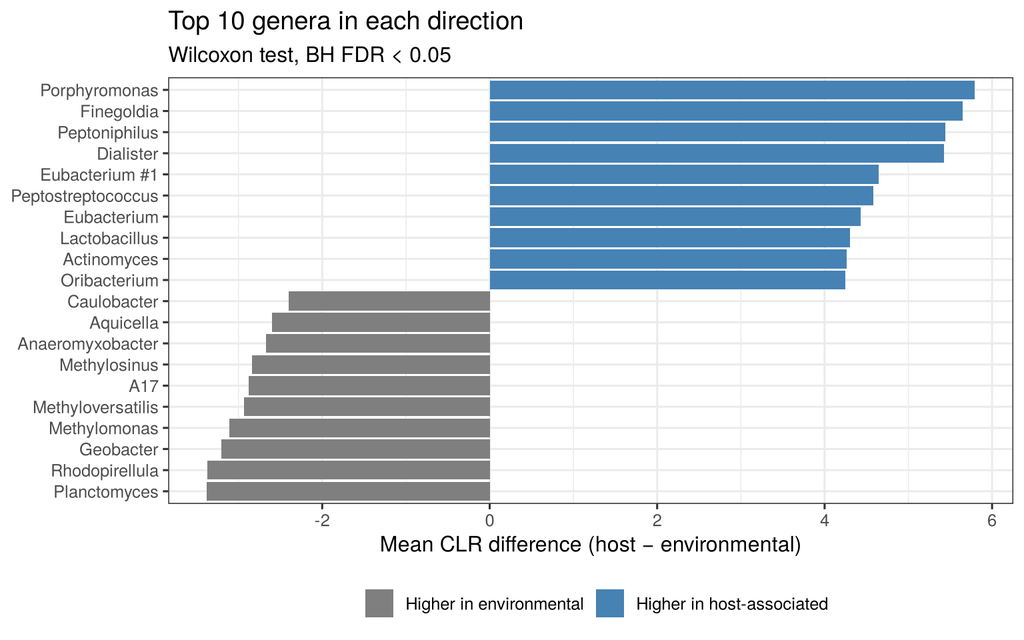

```r
genus <- tax_glom(gp_f, taxrank = "Genus", NArm = TRUE)
gcounts <- as(otu_table(genus), "matrix")
if (taxa_are_rows(genus)) gcounts <- t(gcounts)
gclr <- clr(gcounts)

host <- sample_data(genus)$SampleType %in% c("Feces", "Skin", "Tongue")

res <- data.frame(
  taxon = colnames(gclr),
  genus = as.character(tax_table(genus)[colnames(gclr), "Genus"]),
  phylum = as.character(tax_table(genus)[colnames(gclr), "Phylum"]),
  clr_diff = apply(gclr, 2, function(x) mean(x[host]) - mean(x[!host])),
  p = apply(gclr, 2, function(x) wilcox.test(x[host], x[!host], exact = FALSE)$p.value)
)
res$fdr <- p.adjust(res$p, method = "BH")

sig <- filter(res, fdr < 0.05)
top <- bind_rows(slice_max(sig, clr_diff, n = 10),
                 slice_min(sig, clr_diff, n = 10)) %>%
  arrange(clr_diff) %>%
  mutate(label = make.unique(genus, sep = " #"))   # some genera have >1 taxon

ggplot(top, aes(clr_diff, reorder(label, clr_diff), fill = clr_diff > 0)) +
  geom_col() +
  scale_fill_manual(values = c("grey50", "steelblue"),
                    labels = c("Higher in environmental", "Higher in host-associated")) +
  labs(x = "Mean CLR difference (host − environmental)", y = NULL, fill = NULL,
       title = "Top 10 genera in each direction",
       subtitle = "Wilcoxon test, BH FDR < 0.05") +
  theme(legend.position = "bottom")
```

```r
cat(sum(res$fdr < 0.05), "of", nrow(res), "genera differ at FDR < 0.05\n")
```

```
## 100 of 733 genera differ at FDR < 0.05
```

Host-associated samples are enriched for well-known oral, skin and gut genera, such as *Streptococcus*, *Porphyromonas*, *Finegoldia* and *Lactobacillus*, consistent with prior knowledge. Recovering expected biology like this is a useful check on the pipeline before applying it to new data.

## 6. How much do the results depend on the method?

The differential-abundance result above used one method: CLR with a pseudocount of 0.5, tested with Wilcoxon. A careful analysis should check whether the conclusions hold under other reasonable choices. I compare three approaches on the same genus-level host-vs-environmental question:

- **Relative abundance**: proportions, not compositionally aware
- **CLR (pseudocount 0.5)**: the approach above, where zeros are replaced by a small value
- **Robust CLR**: log-ratios computed only from observed values. Zeros are treated as missing, so it tests abundance *when a genus is present*.

```r
rel_g <- gcounts / rowSums(gcounts)
rclr_g <- as.matrix(decostand(gcounts, method = "rclr"))
rclr_g[gcounts == 0] <- NA

wilcox_p <- function(M) apply(M, 2, function(x) {
  a <- na.omit(x[host]); b <- na.omit(x[!host])
  if (length(a) < 2 || length(b) < 2) return(NA)
  wilcox.test(a, b, exact = FALSE)$p.value
})

genus_labels <- make.unique(as.character(tax_table(genus)[colnames(gcounts), "Genus"]))
methods <- list(
  "Relative abundance" = wilcox_p(rel_g),
  "CLR (pseudocount 0.5)" = wilcox_p(gclr),
  "Robust CLR (present only)" = wilcox_p(rclr_g)
)
sig_sets <- lapply(methods, function(p) genus_labels[which(p.adjust(p, "BH") < 0.05)])

cat("Share of zero counts at genus level:", round(100 * mean(gcounts == 0)), "%\n\n")
```

```
## Share of zero counts at genus level: 47 %
```

```r
data.frame(
  method = names(sig_sets),
  genera_tested = sapply(methods, function(p) sum(!is.na(p))),
  significant_FDR_0.05 = sapply(sig_sets, length),
  row.names = NULL
)
```

```
##                      method genera_tested significant_FDR_0.05
## 1        Relative abundance           733                   66
## 2     CLR (pseudocount 0.5)           733                  100
## 3 Robust CLR (present only)           503                   13
```

```r
jaccard <- function(a, b) round(length(intersect(a, b)) / length(union(a, b)), 2)
cat("\nOverlap between significant sets (Jaccard index):\n")
```

```
##
## Overlap between significant sets (Jaccard index):
```

```r
cat("  Relative abundance vs CLR:       ", jaccard(sig_sets[[1]], sig_sets[[2]]), "\n")
```

```
##   Relative abundance vs CLR:        0.2
```

```r
cat("  CLR vs robust CLR:               ", jaccard(sig_sets[[2]], sig_sets[[3]]), "\n")
```

```
##   CLR vs robust CLR:                0.13
```

```r
cat("  Significant under all three:     ", length(Reduce(intersect, sig_sets)), "genera\n")
```

```
##   Significant under all three:      9 genera
```

The methods agree far less than one might expect. Almost half the genus-level counts are zero, and with relative abundance or pseudocount CLR, a genus present in one group and absent in the other looks like a large difference. Robust CLR asks a narrower question, abundance when present, and finds far fewer differences. So most of the signal here is about **which genera are present in each habitat**, not how abundant shared genera are. Both are valid findings, but they mean different things. A report should say which question it answers.

### Sensitivity to the pseudocount

```r
pc_values <- c(0.1, 0.5, 1)
pc_sig <- lapply(pc_values, function(pc) {
  p <- wilcox_p(clr(gcounts, pseudocount = pc))
  genus_labels[which(p.adjust(p, "BH") < 0.05)]
})
names(pc_sig) <- paste("pseudocount", pc_values)
sapply(pc_sig, length)
```

```
## pseudocount 0.1 pseudocount 0.5   pseudocount 1
##              94             100             113
```

```r
effect <- function(M) apply(M, 2, function(x) mean(x[host]) - mean(x[!host]))
cat("Rank correlation of effect sizes, pseudocount 0.1 vs 1:",
    round(cor(effect(clr(gcounts, 0.1)), effect(clr(gcounts, 1)), method = "spearman"), 2), "\n")
```

```
## Rank correlation of effect sizes, pseudocount 0.1 vs 1: 0.97
```

```r
cat("Overlap of significant genera, pseudocount 0.1 vs 1 (Jaccard):",
    jaccard(pc_sig[[1]], pc_sig[[3]]), "\n")
```

```
## Overlap of significant genera, pseudocount 0.1 vs 1 (Jaccard): 0.78
```

The ranking of genera barely changes with the pseudocount, but the number passing the significance threshold does. The ordering is robust, while the exact list of “significant” genera depends on an arbitrary choice. This is why I’d treat a single significance cut-off as a starting point for follow-up, not a final answer.

## 7. Predicting habitat from community composition

Can a model identify a sample’s habitat from its genus-level CLR profile? With only 23 samples, the main risk is overestimating performance, so I use **leave-one-out cross-validation** (each sample is predicted by a model that never saw it). I also compare against a **shuffled-label baseline**, which shows the accuracy expected by chance.

```r
X <- gclr
colnames(X) <- make.names(genus_labels)
y <- droplevels(sample_data(genus)$SampleType)

loocv <- function(X, y, ntree = 500) {
  pred <- character(length(y))
  for (i in seq_along(y)) {
    fit <- randomForest(X[-i, ], y[-i], ntree = ntree)
    pred[i] <- as.character(predict(fit, X[i, , drop = FALSE]))
  }
  factor(pred, levels = levels(y))
}

pred <- loocv(X, y)
acc <- mean(pred == y)

null_acc <- replicate(50, {
  y_perm <- sample(y)
  mean(loocv(X, y_perm, ntree = 200) == y_perm)
})

cat("Leave-one-out accuracy:        ", round(100 * acc), "%\n")
```

```
## Leave-one-out accuracy:         83 %
```

```r
cat("Shuffled-label accuracy (mean):", round(100 * mean(null_acc)), "%\n")
```

```
## Shuffled-label accuracy (mean): 7 %
```

```r
cat("Shuffled-label 95th percentile:", round(100 * quantile(null_acc, 0.95)), "%\n")
```

```
## Shuffled-label 95th percentile: 26 %
```

The model does far better than chance. A single accuracy figure hides where it goes wrong, so the confusion matrix matters more:

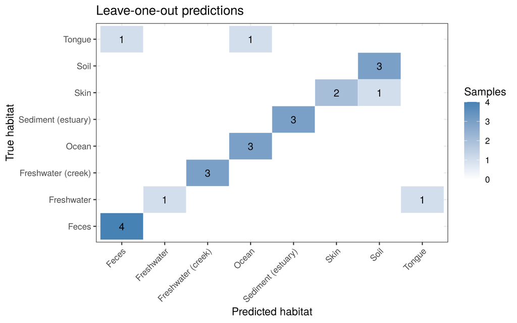

```r
cm <- as.data.frame(table(true = y, predicted = pred))
ggplot(cm, aes(predicted, true, fill = Freq)) +
  geom_tile(colour = "white") +
  geom_text(aes(label = ifelse(Freq > 0, Freq, "")), size = 4) +
  scale_fill_gradient(low = "white", high = "steelblue") +
  labs(x = "Predicted habitat", y = "True habitat", fill = "Samples",
       title = "Leave-one-out predictions") +
  theme(axis.text.x = element_text(angle = 45, hjust = 1))
```

### Where the model fails

The errors are informative:

- **Tongue** has only two samples, so each one is predicted by a model trained on a single tongue example. Neither is classified correctly. This is a sample-size failure, not evidence that tongue communities are indistinguishable.
- **One skin sample is predicted as soil.** This is biologically plausible, since skin is continually exposed to environmental microbes.
- **One freshwater sample is predicted as tongue.** There’s no biological reason for this. It most likely reflects how unstable the model is when a class has only two training samples.

A useful comparison is the simpler, better-powered question of whether a sample is host-associated or environmental:

```r
host_y <- factor(ifelse(host, "Host-associated", "Environmental"))
host_pred <- loocv(X, host_y)
cat("Leave-one-out accuracy, host vs environmental:", round(100 * mean(host_pred == host_y)), "%\n")
```

```
## Leave-one-out accuracy, host vs environmental: 100 %
```

```r
table(true = host_y, predicted = host_pred)
```

```
##                  predicted
## true              Environmental Host-associated
##   Environmental              14               0
##   Host-associated             0               9
```

With more samples per class and a large biological difference, this split is easy. The model’s difficulty lies in the fine habitat distinctions with very few examples each. The practical lesson is that more replicates per condition would improve the model more than a more complex algorithm.

Feature importance from a single random forest is itself random. With 23 samples and over 700 genera, many features carry similar information, and which ones a given forest relies on changes from run to run. To see which signals are **stable**, I fit 20 forests with different seeds, average the importance scores, and count how often each genus appears in the top 15.

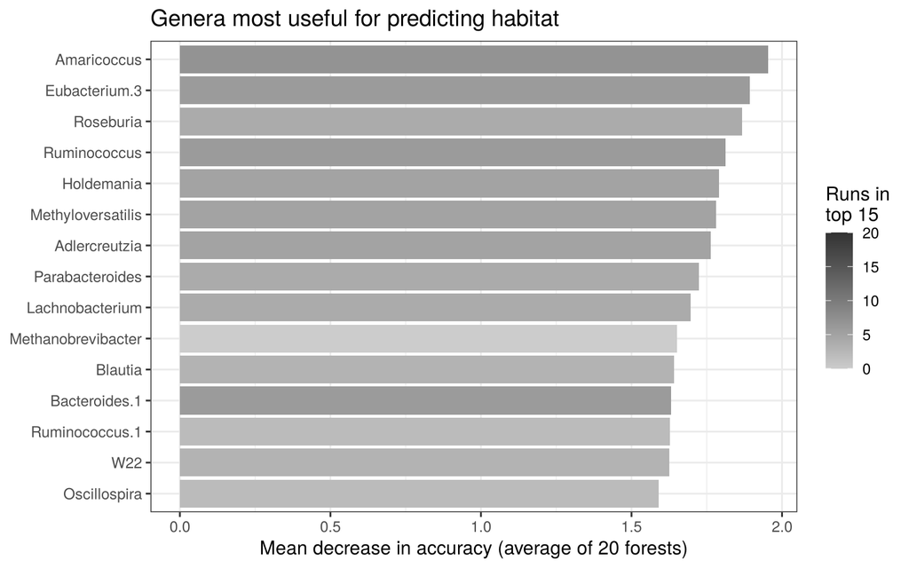

```r
n_runs <- 20
imp_runs <- sapply(seq_len(n_runs), function(seed) {
  set.seed(seed)
  fit <- randomForest(X, y, ntree = 500, importance = TRUE)
  importance(fit, type = 1)[, 1]
})
rownames(imp_runs) <- genus_labels

top15_counts <- rowSums(apply(imp_runs, 2, function(v) rank(-v) <= 15))
imp_df <- data.frame(genus = genus_labels,
                     mean_importance = rowMeans(imp_runs),
                     times_in_top15 = top15_counts) %>%
  slice_max(mean_importance, n = 15)

ggplot(imp_df, aes(mean_importance, reorder(genus, mean_importance), fill = times_in_top15)) +
  geom_col() +
  scale_fill_gradient(low = "grey80", high = "grey20", limits = c(0, n_runs)) +
  labs(x = "Mean decrease in accuracy (average of 20 forests)", y = NULL,
       fill = "Runs in\ntop 15",
       title = "Genera most useful for predicting habitat")
```

```r
cat("Genera in the top 15 in at least half of the runs:",
    sum(top15_counts >= n_runs / 2), "\n")
```

```
## Genera in the top 15 in at least half of the runs: 0
```

The averaged ranking is led by gut-associated anaerobes (for example *Roseburia*, *Ruminococcus*, *Parabacteroides* and *Blautia*), which reflects how distinct the faecal samples are from every other habitat. But no individual genus is reliably important: **no genus** appears in the top 15 in at least half of the 20 runs.

The model’s accuracy is stable, but its explanation is not. Many genera are interchangeable markers of the same habitats, so no single genus should be read as *the* driver. Two general cautions apply: importance shows what a model uses, not what causes a difference, and with this few samples any ranking would need confirming on independent data.

## Limitations

- **Small groups:** 2–4 samples per habitat limit statistical power, and habitat is confounded with study design.
- **Zeros and pseudocounts:** as section 6 shows, results depend on how zeros are handled. Dedicated methods (for example ALDEx2 or ANCOM-BC) model this more formally and would be the next step.
- **Model evaluation:** leave-one-out cross-validation on 23 samples gives a noisy accuracy estimate. Habitat is also confounded with the original study design, so a model this good on new, independently collected samples should not be assumed.
- **Relative, not absolute:** neither relative abundances nor CLR values say whether a taxon’s absolute load changed. That would need spike-ins or total-load measurements.
- **Reference database:** genus-level labels depend on the reference taxonomy. Unassigned taxa (dropped at genus level here) can hide real differences, especially in poorly characterised environments such as soil.